# Bayesian Bivariate Random-effects Meta Analysis - Product Normal Formulation (PNF)

- Show All Code
- Hide All Code
- View Source

Author

Ananda Biswas

Published

November 3, 2026

## Required Packages

**Show/Hide Code**

```r
library(openxlsx)

library(gt)
library(tidyverse)

library(cmdstanr)
```

## Loading Data

**Show/Hide Code**

```r
df1 <- read.xlsx(data.path, sheet = 1)
```

## Initial Sanity Checks

**Show/Hide Code**

```r
str(df1)
```

```
'data.frame':   34 obs. of  10 variables:
 $ Study    : chr  "Study 1" "Study 2" "Study 3" "Study 4" ...
 $ HR.OS    : num  0.741 0.756 1.277 1.01 0.43 ...
 $ OS.ln.HR : num  -0.3 -0.28 0.244 0.01 -0.844 ...
 $ OS.se    : num  0.18 0.25 0.165 0.141 0.189 0.198 0.269 0.126 0.184 0.068 ...
 $ HR.PFS   : num  0.72 0.92 1.12 1.31 0.54 ...
 $ PFS.ln.HR: num  -0.3285 -0.0834 0.1125 0.27 -0.6162 ...
 $ PFS.se   : num  0.177 0.255 0.168 0.134 0.17 0.186 0.264 0.126 0.137 0.06 ...
 $ n1       : num  82 34 73 136 95 75 42 125 109 622 ...
 $ n2       : num  73 42 74 138 86 69 39 125 110 618 ...
 $ non.prop : chr  "0" "0" "0" "1" ...
```

**Show/Hide Code**

```r
dim(df1)
```

```
[1] 34 10
```

Preview of NSCLC Data

| Study | HR.OS | OS.ln.HR | OS.se | HR.PFS | PFS.ln.HR | PFS.se | n1 | n2 | non.prop |
| --- | --- | --- | --- | --- | --- | --- | --- | --- | --- |
| Study 1 | 0.7408182 | -0.3000 | 0.180 | 0.7200029 | -0.3285 | 0.177 | 82 | 73 | 0 |
| Study 2 | 0.7557837 | -0.2800 | 0.250 | 0.9199831 | -0.0834 | 0.255 | 34 | 42 | 0 |
| Study 3 | 1.2769827 | 0.2445 | 0.165 | 1.1190723 | 0.1125 | 0.168 | 73 | 74 | 0 |
| Study 4 | 1.0100502 | 0.0100 | 0.141 | 1.3099645 | 0.2700 | 0.134 | 136 | 138 | 1 |
| Study 5 | 0.4299871 | -0.8440 | 0.189 | 0.5399925 | -0.6162 | 0.170 | 95 | 86 | 1 |
| Study 6 | 0.6999825 | -0.3567 | 0.198 | 0.7499866 | -0.2877 | 0.186 | 75 | 69 | 1 |

## Derived Quantities

Calculate the weight of individual studies included in the data-set. These weights will be used to display studies in the trial-level association plot.

**Show/Hide Code**

```r
df1$weight <- 1 / (df1$OS.se)^2
```

## Generating Treatment Effect on Surrogate Endpoint in New Trials

Generate $1000$ new points in the observed range of `HR.PFS` in the data-set. These points represent `HR.PFS` of $1000$ future trials.

**Show/Hide Code**

```r
range(df1$HR.PFS)
```

```
[1] 0.2034164 2.8662369
```

**Show/Hide Code**

```r
new.data <- data.frame(PFS.ln.HR = log(seq(0.2,3, length=1000)))
```

## Model

The BRMA model for *correlated* and *normally distributed* treatment effects on two outcomes $Y_{1i}$ and $Y_{2i}$ is usually presented in the following form (Bujkiewicz et al. 2026) (Bujkiewicz et al. 2017):

$$\begin{pmatrix}
Y_{1i}\\
Y_{2i}
\end{pmatrix}
\sim
\mathcal{N}_2\left(
\begin{pmatrix}
\delta_{1i}\\
\delta_{2i}
\end{pmatrix},
\boldsymbol{\Sigma}_i
\right),
\qquad
\boldsymbol{\Sigma}_i =
\begin{pmatrix}
\sigma_{1i}^2 & \sigma_{1i}\sigma_{2i}\rho_{wi}\\
\sigma_{1i}\sigma_{2i}\rho_{wi} & \sigma_{2i}^2
\end{pmatrix} \tag{1}$$

$$\begin{pmatrix}
\delta_{1i}\\
\delta_{2i}
\end{pmatrix}
\sim
\mathcal{N}_2\left(
\begin{pmatrix}
d_1\\
d_2
\end{pmatrix},
\mathbf{T}
\right),
\qquad
\mathbf{T} =
\begin{pmatrix}
\tau_1^2 & \tau_1\tau_2\rho_b\\
\tau_1\tau_2\rho_b & \tau_2^2
\end{pmatrix}. \tag{2}$$

In this model, the treatment effects on the two endpoints $Y_{1i}$ and $Y_{2i}$ are assumed to estimate the *correlated* true effects $\delta_{1i}$ and $\delta_{2i}$ with corresponding within-study variances $\sigma_{1i}^2$ and $\sigma_{2i}^2$ of the estimates and the **within-study correlation** $\rho_{wi}$ between them in each study $i$. In this *hierarchical framework*, these true study-level effects are assumed *exchangeable*. This means that all $\delta_{1i}$ and $\delta_{2i}$ are “similar” in a way which assumes that the trial labels, $i$, attached to these treatment effects are irrelevant. Since they are exchangeable and correlated, they follow a common bivariate normal distribution with means $(d_1,d_2)$ corresponding to the treatment effects on the two outcomes, between-studies variances $\tau_1^2$ and $\tau_2^2$ and a **between-studies correlation** $\rho_b$. Equation 1 and Equation 2 represent the **within-study model** and the **between-studies model** respectively.

The BRMA model 1, 2 can be parameterized in an alternative form. Specifically, the between-studies model 2 is represented in the product normal formulation (PNF) (a product of univariate conditional normal distributions), whereas the within-study model remains the same:

$$\begin{pmatrix}
Y_{1i}\\
Y_{2i}
\end{pmatrix}
\sim
\mathcal{N}_2\left(
\begin{pmatrix}
\delta_{1i}\\
\delta_{2i}
\end{pmatrix},
\boldsymbol{\Sigma}_i
\right),
\qquad
\boldsymbol{\Sigma}_i =
\begin{pmatrix}
\sigma_{1i}^2 & \sigma_{1i}\sigma_{2i}\rho_{wi}\\
\sigma_{1i}\sigma_{2i}\rho_{wi} & \sigma_{2i}^2
\end{pmatrix} \tag{3}$$

$$\left\{
\begin{aligned}
&\delta_{1i} \sim \mathcal{N}(\eta_1, \psi_1^2)\\
&\delta_{2i} \mid \delta_{1i} \sim \mathcal{N}(\eta_{2i}, \psi_2^2)\\
&\eta_{2i} = \lambda_0 + \lambda_1\delta_{1i}.
\end{aligned}
\right.
\tag{4}$$

Note that,

- in 4 $\delta_{1i}$ has a normal distribution, also $\delta_{2i}$ has a normal distribution. So the joint distribution of $\delta_{1i}, \delta_{2i}$

$$p(\delta_{1i}, \delta_{2i}) = p(\delta_{1i}) \cdot p(\delta_{2i} \mid \delta_{1i})$$

is a product of two normal distributions. Thus the name *Product Normal Formulation* is adapted.

- the true treatment effects are correlated and are assumed exchangeable, and therefore are modelled here as random effects with a **linear relationship**.

The main difference between BRMA-PNF and Daniels & Hughes Bayesian bivariate meta analysis framework (Daniels and Hughes 1997) is in the assumption of random effects (exchangeability) for the true treatment effects on the surrogate endpoints $\delta_{1i} \sim N(\eta_1, \psi_1^2)$ in the BRMA-PNF model, whilst Daniels and Hughes assumed fixed affects on the surrogate endpoint. When this assumption of exchangeability is reasonable, this model can lead to *more precise predictions* due to increased borrowing of information across studies (for both outcomes).

## Surrogacy Criteria

The surrogacy criteria in BRMA-PNF model are *same* as described in Daniels and Hughes Bayesian bivariate meta analysis (Bujkiewicz et al. 2026). A strong surrogate relationship is the one with

- $\lambda_0 = 0$, to ensure that no treatment effect on the surrogate endpoint implies no treatment effect on the final clinical outcome,
- $\lambda_1 \neq 0$, establishing a relationship between treatment effects on the surrogate and final clinical outcomes,
- $\psi_2^2 = 0$, implying that we can predict $\delta_{2i}$ perfectly given $\delta_{1i}$.

In practice, a surrogate relationship is considered **strong** if all the following are true:

- the $95\%$ credible interval for the intercept $\lambda_0$ includes zero,
- the $95\%$ credible interval for the slope $\lambda_1$ does not include zero,
- the conditional variance $\psi_2^2$ along with its upper interval is small.

## Model Fitting

### Preparing data for STAN

**Show/Hide Code**

```r
N <- nrow(df1)

BRMA.PNF.data <- list(
  N = N,
  y1 = df1$PFS.ln.HR,
  y2 = df1$OS.ln.HR,
  se1 = df1$PFS.se,
  se2 = df1$OS.se
)
```

### STAN Model

For surrogate endpoint evaluation, our parameters of interest are $\lambda_0$, $\lambda_1$, $\rho_b$ and $\psi_2^2$ in the sense that we seek posterior estimates of these parameters only. The hierarchical framework presented in 3, 4 has too many parameters. We derive a marginalized model with as small number of parameters as possible in the following. Note that, *less the number of parameters, easier is the posterior sampling and lesser the divergences; unnecessary parameters also bring their difficult geometries with them*.

From 3 and 4, the below follows:

$$E[Y_{1i}] = E[E[Y_{1i} \mid \delta_{1i}]] = E[\delta_{1i}] = \eta_1$$

$$\begin{aligned}
E[Y_{2i}] &= E[E[Y_{2i} \mid \delta_{2i}]] \\[0.7em]
&= E[\delta_{2i}] \\[0.7em]
&= E[E[\delta_{2i} \mid \delta_{1i}]] \\[0.7em]
&= E[\lambda_0 + \lambda_1\delta_{1i}] \\[0.7em]
&= \lambda_0 + \lambda_1\eta_1
\end{aligned}$$

$$\begin{aligned}
\operatorname{Var}(Y_{1i})
&= E[\operatorname{Var}(Y_{1i} \mid \delta_{1i})]
+ \operatorname{Var}(E[Y_{1i} \mid \delta_{1i}]) \\[0.7em]
&= E(\sigma_{1i}^2) + \operatorname{Var}(\delta_{1i}) \\[0.7em]
&= \sigma_{1i}^2 + \psi_1^2
\end{aligned}$$

$$\begin{aligned}
\operatorname{Var}(Y_{2i})
&= E[\operatorname{Var}(Y_{2i} \mid \delta_{2i})]
+ \operatorname{Var}(E[Y_{2i} \mid \delta_{2i}]) \\[0.7em]
&= E(\sigma_{2i}^2) + \operatorname{Var}(\delta_{2i}) \\[0.7em]
&= \sigma_{2i}^2
+ E[\operatorname{Var}(\delta_{2i} \mid \delta_{1i})]
+ \operatorname{Var}(E[\delta_{2i} \mid \delta_{1i}]) \\[0.7em]
&= \sigma_{2i}^2
+ E[\psi_2^2]
+ \operatorname{Var}(\lambda_0 + \lambda_1 \delta_{1i}) \\[0.7em]
&= \sigma_{2i}^2 + \psi_2^2 + \lambda_1^2\psi_1^2.
\end{aligned}$$

$$\begin{aligned}
\operatorname{Cov}(Y_{1i}, Y_{2i})
&=
E[\operatorname{Cov}(Y_{1i}, Y_{2i} \mid \delta_{1i}, \delta_{2i})]
+
\operatorname{Cov}(E[Y_{1i} \mid \delta_{1i}, \delta_{2i}], E[Y_{2i} \mid \delta_{1i}, \delta_{2i}]) \\[0.7em]
&= E(\sigma_{1i}\sigma_{2i}\rho_{wi}) + \operatorname{Cov}(\delta_{1i}, \delta_{2i}) \\[0.7em]
&= \sigma_{1i}\sigma_{2i}\rho_{wi} + \operatorname{Cov}(\delta_{1i}, E[\delta_{2i} \mid \delta_{1i}]) \\[0.7em]
&= \sigma_{1i}\sigma_{2i}\rho_{wi} + \operatorname{Cov}(\delta_{1i}, \lambda_0 + \lambda_1\delta_{1i}) \\[0.7em]
&= \sigma_{1i}\sigma_{2i}\rho_{wi} + \lambda_1\operatorname{Cov}(\delta_{1i}, \delta_{1i}) \\[0.7em]
&= \sigma_{1i}\sigma_{2i}\rho_{wi} + \lambda_1\operatorname{Var}(\delta_{1i}) \\[0.7em]
&= \sigma_{1i}\sigma_{2i}\rho_{wi} + \lambda_1\psi_1^2
\end{aligned}$$

Hence, combining 3 and 4, we obtain a bivariate normal distribution

$$\begin{pmatrix}
Y_{1i}\\
Y_{2i}
\end{pmatrix}
\sim
\mathcal{N}\left(
\begin{pmatrix}
\eta_1\\
\lambda_0 + \lambda_1\eta_1
\end{pmatrix},
\begin{pmatrix}
\sigma_{1i}^2 + \psi_1^2 &
\sigma_{1i}\sigma_{2i}\rho_{wi} + \lambda_1\psi_1^2\\
\sigma_{1i}\sigma_{2i}\rho_{wi} + \lambda_1\psi_1^2 &
\sigma_{2i}^2 + \psi_2^2 + \lambda_1^2\psi_1^2
\end{pmatrix}
\right).
\tag{5}$$

We use Equation 5 in our STAN implementation of BRMA PNF.

Instead of placing independent non-informative prior distributions on all the parameters of model 4, relationships between these parameters and the elements of the between-studies covariance matrix $\boldsymbol{T}$ in the between-studies model 2 are derived to allow to take into account the inter-relationship between the parameters. These relationships have the following forms

$$\psi_1^2 = \tau_1^2, \qquad
\psi_2^2 = \tau_2^2 - \lambda_1^2\tau_1^2, \qquad
\lambda_1 = \dfrac{\tau_2}{\tau_1}\rho_b.
\tag{6}$$

From a comparison of 2 and 4, $\psi_1^2 = \tau_1^2$ is trivial. Moreover, from 2 it follows,

$$\delta_{2i} \mid \delta_{1i} \sim \mathcal{N} \left( d_2 + \rho_b \dfrac{\tau_2}{\tau_1}(\delta_{1i} - d_1), \tau_2^2(1 - \rho_b^2)\right).$$

Comparing 4 with the above gives, $\lambda_1 = \dfrac{\tau_2}{\tau_1}\rho_b$ and $\psi_2^2 = \tau_2^2(1 - \rho_b^2)$. Thus

$$\begin{aligned}
\psi_2^2 &= \tau_2^2 - \tau_2^2 \cdot \rho_b^2 \\[0.5em]
&= \tau_2^2 - \lambda_1^2 \tau_1^2 \;\; \text{as } \lambda_1 \tau_1 = \tau_2 \rho_b
\end{aligned}$$

Prior distributions are placed on the following parameters:

$$\lambda_0 \sim \mathcal{N}(0, 1000)$$

$$\eta_1 \sim \mathcal{N}(0, 1000)$$

$$\tau_1, \tau_2 \sim U(0, 2)$$

$$\rho_b \sim U(-1, 1)$$

As IPD are not available, assume that the $\rho_{wi}$’s for the trials with no data available are equal to some common value $\rho_w$, we **assume** a positive association between `HR.OS` and `HR.PFS`, accordingly we set a priori
$$\rho_w \sim U(0, 1).$$

Additionally, the above derived relationships 6 give the *implied prior distribution* on the parameters $\lambda_1, \psi_1$ and $\psi_2$.

The PNF provides *better control* over the prior distributions placed on specific parameters of the model (compared to BRMA with Wishart prior distribution).

Here is a suitable STAN model.

```stan
data {
  int<lower=1> N;

  vector[N] y1;
  vector[N] y2;

  vector<lower=0>[N] se1;
  vector<lower=0>[N] se2;
}

parameters {
  real eta1;

  real lambda0;

  real<lower=0, upper=2> tau1;
  real<lower=0, upper=2> tau2;

  real<lower=-0.999, upper=0.999> rho_b;

  real<lower=0, upper=0.999> rho_w;
}

transformed parameters {

  real<lower=0> psi1 = tau1;
  real<lower=0> psi1_sq = square(tau1);

  real lambda1 = (tau2 / tau1) * (rho_b);

  real<lower=0> psi2_sq = square(tau2) - square(lambda1) * square(tau1);
  real<lower=0> psi2 = sqrt(psi2_sq);
}

model {

  // combined model

  for (i in 1:N){

    // observation
    vector[2] y_obs = [y1[i], y2[i]]';

    // mean
    vector[2] mu = [eta1, lambda0 + lambda1 * eta1]';

    // covariance matrix
    matrix[2,2] Sigma;

    Sigma[1,1] = square(se1[i]) + psi1_sq;
    Sigma[1,2] = se1[i] * se2[i] * rho_w + lambda1 * psi1_sq;

    Sigma[2,1] = Sigma[1,2];
    Sigma[2,2] = square(se2[i]) + psi2_sq + square(lambda1) * psi1_sq;

    // distribution
    y_obs ~ multi_normal(mu, Sigma);
  }

  // priors

  eta1 ~ normal(0, sqrt(1000));

  lambda0 ~ normal(0, sqrt(1000));

  tau1 ~ uniform(0, 2);
  tau2 ~ uniform(0, 2);

  rho_b ~ uniform(-0.999, 0.999);
  rho_w ~ uniform(0, 0.999);
}
```

### Model Compilation

**Show/Hide Code**

```r
BRMA.PNF.model <- cmdstan_model(BRMA.PNF.model)
```

### Running HMC

**Show/Hide Code**

```r
n.chains <- 3
n.samples.per.chain <- 150000

n.posterior.samples <- n.chains * n.samples.per.chain
```

**Show/Hide Code**

```r
fit.BRMA.PNF <- BRMA.PNF.model$sample(
  data = BRMA.PNF.data,
  chains = n.chains,
  parallel_chains = n.chains,
  iter_warmup = 30000,
  iter_sampling = n.samples.per.chain,
  adapt_delta = 0.95,
  max_treedepth = 15,
  seed = 14,
  refresh = 0
)
```

### STAN Diagnostics

**Show/Hide Code**

```r
fit.BRMA.PNF$cmdstan_diagnose()
```

```
Checking sampler transitions treedepth.
Treedepth satisfactory for all transitions.

Checking sampler transitions for divergences.
No divergent transitions found.

Checking E-BFMI - sampler transitions HMC potential energy.
E-BFMI satisfactory.

Rank-normalized split effective sample size satisfactory for all parameters.

Rank-normalized split R-hat values satisfactory for all parameters.

Processing complete, no problems detected.
```

## Posterior Summaries of Parameters of Interest

### Posterior Draws

**Show/Hide Code**

```r
posterior.draws <- fit.BRMA.PNF$draws(
  variables = c("lambda0", "lambda1", "psi2", "rho_b", "psi1_sq", "psi2_sq"),
  format = "matrix"
)
```

**Show/Hide Code**

```r
data.frame(head(posterior.draws)) |>
  gt()
```

| lambda0 | lambda1 | psi2 | rho_b | psi1_sq | psi2_sq |
| --- | --- | --- | --- | --- | --- |
| 0.02035798 | 0.6506220 | 0.02833631 | 0.9865626 | 0.06916119 | 0.0008029466 |
| -0.02972513 | 0.4793464 | 0.13368826 | 0.8759157 | 0.25637859 | 0.0178725510 |
| -0.05605794 | 0.4666220 | 0.10800256 | 0.9150633 | 0.27577927 | 0.0116645540 |
| -0.05421843 | 0.4428638 | 0.11217302 | 0.8991581 | 0.27083607 | 0.0125827850 |
| -0.03755127 | 0.5986224 | 0.12560781 | 0.9142366 | 0.22415413 | 0.0157773220 |
| -0.00156612 | 0.5235028 | 0.09716060 | 0.8998425 | 0.14657985 | 0.0094401829 |

### Correlation

**Show/Hide Code**

```r
corr.target.surrogate <- mean(posterior.draws[, "rho_b"])
corr.target.surrogate |> round(3)
```

```
[1] 0.856
```

**Show/Hide Code**

```r
corr.target.surrogate.ci <- quantile(posterior.draws[, "rho_b"], probs = c(0.025, 0.975))
corr.target.surrogate.ci |> round(3)
```

```
 2.5% 97.5%
0.541 0.994
```

### Examining Surrogacy Criteria

**Show/Hide Code**

```r
intercept.estimate <- mean(posterior.draws[, "lambda0"])
intercept.estimate |> round(4)
```

```
[1] -0.0067
```

**Show/Hide Code**

```r
intercept.ci <- quantile(posterior.draws[, "lambda0"], probs = c(0.025, 0.975))
intercept.ci |> round(4)
```

```
   2.5%   97.5%
-0.0800  0.0646
```

Estimated $\lambda_0$ is approximately $0$ and its $95\%$ credible interval contains $0$. So criteria $1$ is satisfied. ✅

**Show/Hide Code**

```r
slope.estimate <- mean(posterior.draws[, "lambda1"])
slope.estimate |> round(4)
```

```
[1] 0.5448
```

**Show/Hide Code**

```r
slope.ci <- quantile(posterior.draws[, "lambda1"], probs = c(0.025, 0.975))
slope.ci |> round(4)
```

```
  2.5%  97.5%
0.2693 0.8089
```

Estimated $\lambda_1$ is not $0$ and its $95\%$ credible interval excluded $0$, so criteria $2$ is satisfied. ✅

**Show/Hide Code**

```r
conditional.variance.estimate <- mean(posterior.draws[, "psi2_sq"])
conditional.variance.estimate |> round(4)
```

```
[1] 0.0134
```

**Show/Hide Code**

```r
conditional.variance.ci <- quantile(posterior.draws[, "psi2_sq"], probs = c(0.025, 0.975))
conditional.variance.ci |> round(4)
```

```
  2.5%  97.5%
0.0007 0.0380
```

Estimated $\psi_2^2$ is close to $0$ along with the upper bound of its $95\%$ credible interval. So criteria $3$ is also satisfied. ✅

## Prediction of TE on Clinical Outcome in New Trials

Now use posterior samples to calculate the predictions on new future trials, credible intervals and prediction intervals. These are the main components of **trial-level association plot**.

Create a design matrix `X` representing new studies on which we will make future predictions.

**Show/Hide Code**

```r
X <- matrix(c(rep(1, 1000), new.data$PFS.ln.HR),
            nrow = 1000, ncol = 2, byrow = FALSE)
```

For each new trial in `X`, corresponding to $450000$ posterior samples of the parameters, there will be $450000$ predictions of `log.HR.OS`. Below is a matrix operation to obtain all the $1000 \times 450000$ predictions.

**Show/Hide Code**

```r
new.eta.2 <- X %*% t(posterior.draws[, c("lambda0", "lambda1")])
```

Each row of `new.eta.2` represents $450000$ posterior draws of `log.HR.OS` *i.e.* the response variable, corresponding to a new `log.HR.PFS` of a new trial.

### Point Estimates

For a new trial, to get a prediction of `log.HR.OS`, we must calculate the mean of posterior samples.

**Show/Hide Code**

```r
BRMA.PNF.fit <- apply(new.eta.2, 1, mean)
```

`BRMA.PNF.fit` has $1000$ predictions corresponding to $1000$ new future trials.

### Credible Intervals

Credible intervals are obtained from the quantiles of the posterior distribution. Below is the calculation for the $95\%$ credible intervals for the predictions on new trials.

**Show/Hide Code**

```r
BRMA.PNF.ci <- t(apply(new.eta.2, 1, quantile, probs = c(0.025, 0.975)))
```

### Prediction Intervals

Prediction intervals are obtained from the quantiles of the posterior predictive distribution.

We want the predictive distribution of $\delta_{2, \text{new}} :$ the true treatment effect on clinical outcome in a future trial.

**Show/Hide Code**

```r
inject.variance <- posterior.draws[, "psi2_sq"] + posterior.draws[, "lambda1"]^2 * posterior.draws[, "psi1_sq"]

u <- rnorm(n.posterior.samples, 0, sd = sqrt(inject.variance))

BRMA.PNF.pred <- new.eta.2 +
  matrix(rep(u, 1000), nrow = 1000, ncol = n.posterior.samples, byrow = TRUE)
```

**Show/Hide Code**

```r
BRMA.PNF.pi <- t(apply(BRMA.PNF.pred, 1, quantile, probs = c(0.025, 0.975)))
```

## Trial-level Association Plot

**Show/Hide Code**

```r
BRMA.PNF.pred.df <- data.frame(HR.PFS = exp(new.data$PFS.ln.HR),
                            HR.OS = exp(BRMA.PNF.fit),
                            lower.ci = exp(BRMA.PNF.ci[,1]),
                            upper.ci = exp(BRMA.PNF.ci[,2]),
                            lower.pi = exp(BRMA.PNF.pi[,1]),
                            upper.pi = exp(BRMA.PNF.pi[,2]))
```

**Show/Hide Code**

```r
BRMA.PNF.association.plot <- ggplot(df1, aes(x = HR.PFS, y = HR.OS)) +
  geom_ribbon(aes(x = HR.PFS, ymin = lower.ci, ymax = upper.ci), data = BRMA.PNF.pred.df, alpha = 0.6, fill = "steelblue") +
  geom_ribbon(aes(x = HR.PFS, ymin = lower.pi, ymax = upper.pi), data = BRMA.PNF.pred.df, alpha = 0.4, fill = "lightblue") +
  geom_line(aes(x = HR.PFS, y = HR.OS), data = BRMA.PNF.pred.df,
            col = "steelblue", linewidth = 1, stat = 'identity') +
  geom_point(aes(size = weight), col = "gray30", fill = "orange", shape = 21, data = df1) +
  scale_x_continuous(transform = "log",
                     limits = c(0.2, 3.1),
                     breaks=c(0.1,0.2,0.3,0.4,0.5,0.7,1,1.2,1.5,2,3),
                     expand = c(0.01, 0.01)) +
  scale_y_continuous(transform = "log",
                     limits = c(min(BRMA.PNF.pred.df$lower.pi), max(BRMA.PNF.pred.df$upper.pi)),
                     breaks=c(0.1,0.2,0.3,0.4,0.5,0.7,1,1.2,1.5,2,3),
                     expand = c(0.01, 0.01)) +
  geom_hline(yintercept = 1, linetype = "dashed", colour = "red") +
  xlab("Progression-free survival hazard ratio (log scale)")+
  ylab(paste("Overall survival hazard ratio" , "\n", "\U00B1", "95% credible and prediction intervals (log scale)")) +
  ggtitle("Bivariate Random-effects Meta Analysis - Product Normal Formulation") +
  theme_bw() +
  scale_colour_hue("trial") +
  theme(legend.position = "none")
```

**Show/Hide Code**

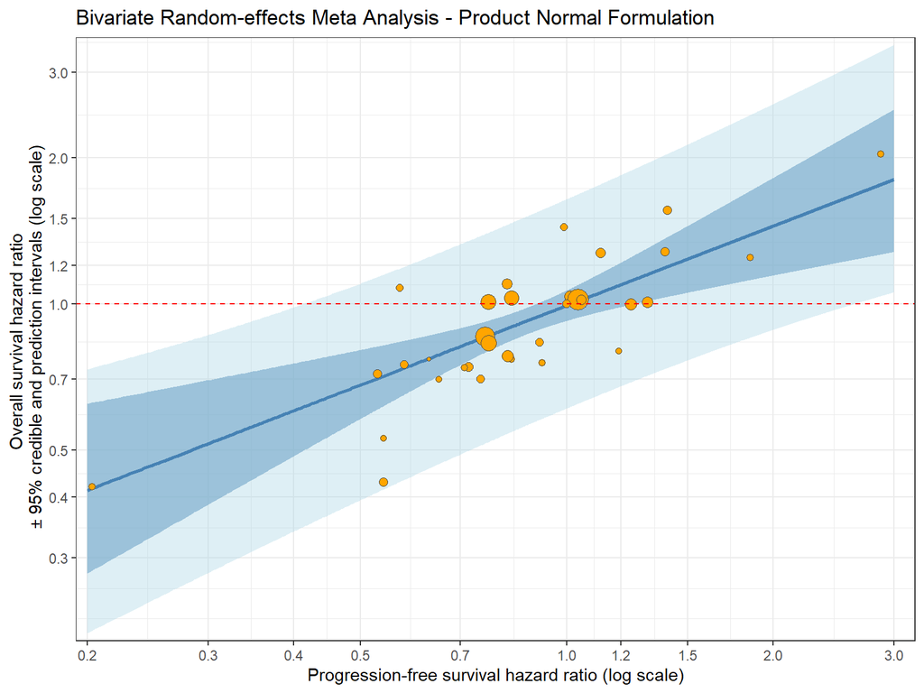

```r
BRMA.PNF.association.plot
```

## Surrogate Threshold Effect

Surrogate Threshold Effect is defined as *the minimum treatment effect on the surrogate necessary to predict a nonzero effect on the true endpoint* in a future trial. $\log(HR) < 0$ implies a *beneficial* treatment effect. So STE was computed as the intersection of the upper $95\%$ prediction interval with the horizontal line for no treatment effect (i.e., in which the HR for OS equals $1$ or $\log(HR) = 0$).

**Show/Hide Code**

```r
candidate.HR.PFS <- BRMA.PNF.pred.df %>%
  filter(upper.pi < 1) %>%
  pull(HR.PFS)

BRMA.PNF.STE <- max(candidate.HR.PFS)
BRMA.PNF.STE |> round(3)
```

```
[1] 0.413
```

## References

Bujkiewicz, Sylwia, Felix Achana, Tasos Papanikos, Richard D. Riley, and Keith R. Abrams. 2026. *TSD 20: Multivariate meta-analysis of summary data for combining treatment effects on correlated outcomes and evaluating surrogate endpoints*. September. https://doi.org/10.15131/shef.data.33848854.v1.

Bujkiewicz, Sylwia, John R Thompson, Enti Spata, and Keith R Abrams. 2017. “Uncertainty in the Bayesian Meta-Analysis of Normally Distributed Surrogate Endpoints.” *Statistical Methods in Medical Research* 26 (5): 2287–318. https://doi.org/10.1177/0962280215597260.

Daniels, Michael J., and Michael D. Hughes. 1997. “Meta-Analysis for the Evaluation of Potential Surrogate Markers.” *Statistics in Medicine* 16 (17): 1965–82. https://doi.org/https://doi.org/10.1002/(SICI)1097-0258(19970915)16:17<1965::AID-SIM630>3.0.CO;2-M.